# Peer Assessment 1

Catherine

## Loading and preprocessing the data

The data was read as the object “activity” and then, the variable date was converted for a Date format:

```r
activity <- read.csv("activity.csv")
activity$date <- as.Date(activity$date)
```

## What is mean total number of steps taken per day?

For answer this question, first we have to calculate the total number of steps taken per day. For this, I used the tapply function:

```r
total_steps <- tapply(activity$steps, activity$date, sum, na.rm= T)
```

Then, I made a histogram of the total number of steps taken each day:

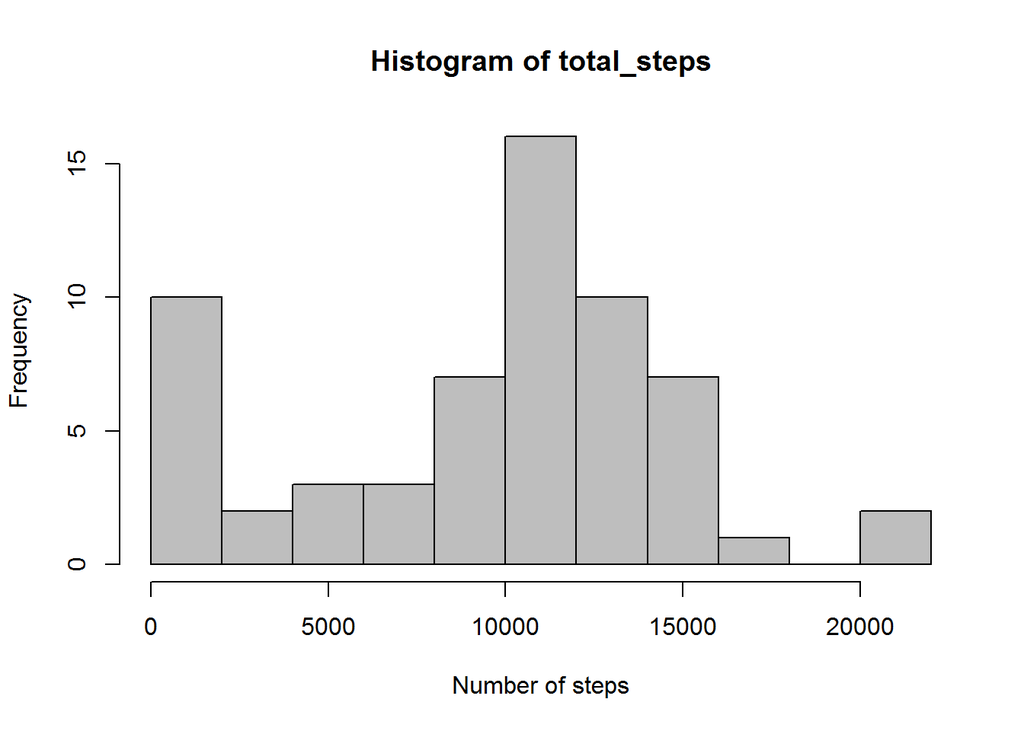

[figure not shown]

```r
hist(total_steps, breaks = 10, col="gray", xlab="Number of steps")
```

The mean and median of the total number of steps taken per day are:

```r
mean(total_steps)
```

```
## [1] 9354.23
```

```r
median(total_steps)
```

```
## [1] 10395
```

## What is the average daily activity pattern?

A time series plot of the 5-minute interval (x-axis) and the average number of steps taken, averaged across all days (y-axis):

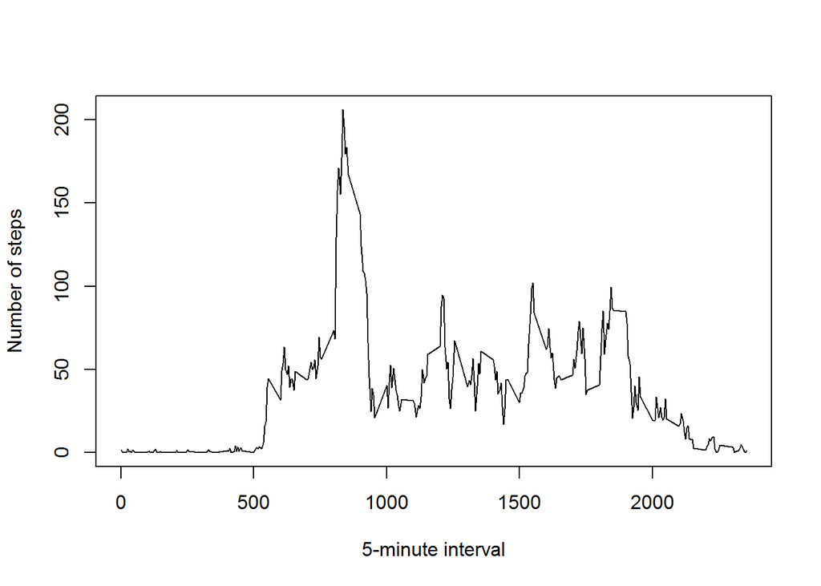

[figure not shown]

```r
daily_pat <- tapply(activity$steps, activity$interval, mean, na.rm= T)
plot(unique(activity$interval), daily_pat, type="l", xlab="5-minute interval",
     ylab= "Number of steps")
```

Which 5-minute interval, on average across all the days in the dataset, contains the maximum number of steps?

```r
daily_pat[which.max(daily_pat)]
```

```
##      835
## 206.1698
```

## Imputing missing values

The total number of missing values in the dataset is:

```r
sum(is.na(activity$steps))
```

```
## [1] 2304
```

For filling in all of the missing values in the dataset I used the mean of the corresponding 5-minute interval, with the following strategy:

```r
fill_steps <- integer(nrow(activity))
for(i in 1:nrow(activity)){
        if(is.na(activity$steps[i]) == TRUE) {
                fill_steps[i] <- mean(activity$steps[which(activity$interval==activity$interval[i])], na.rm=T)
        }else{
                fill_steps[i] <- activity$steps[i]
        }
}
```

Then, I created a new dataset that is equal to the original dataset but with the missing data filled in:

```r
activity_fill <- data.frame(steps= fill_steps, date = activity$date, interval= activity$interval)
```

Make a histogram of the total number of steps taken each day and calculate and report the mean and median total number of steps taken per day.

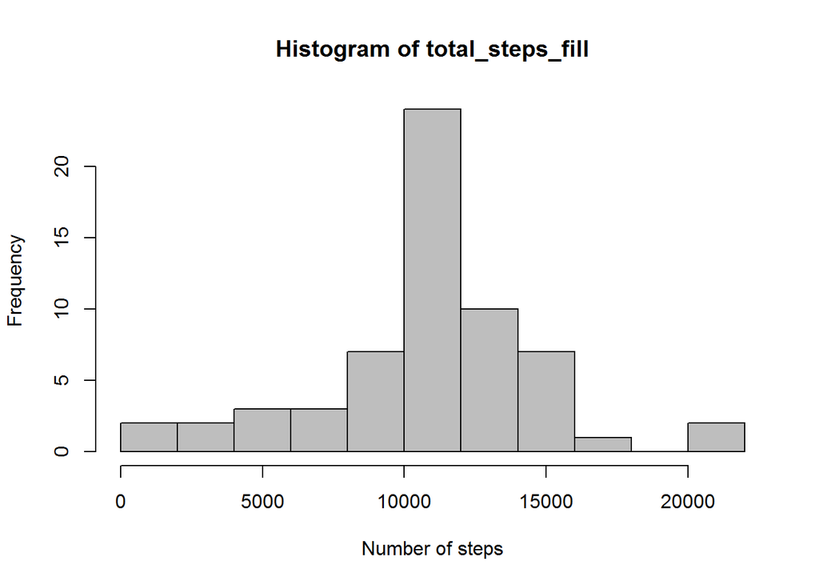

[figure not shown]

```r
total_steps_fill <- tapply(activity_fill$steps, activity_fill$date, sum, na.rm= T)
hist(total_steps_fill, breaks = 10, col="gray", xlab="Number of steps")
```

```r
mean(total_steps_fill)
```

```
## [1] 10766.19
```

```r
median(total_steps_fill)
```

```
## [1] 10766.19
```

## Are there differences in activity patterns between weekdays and weekends?

I created a new factor variable (“week”) in the dataset with two levels – “weekday” and “weekend”:

```r
activity_fill$week <- factor(ifelse(weekdays(activity_fill$date, abbreviate= T)
                                    %in% c("seg","ter","qua","qui","sex"),
                                    "weekday", "weekend"))
```

Then, I used the dplyr package to summarize the number of steps according the variables “week” and “interval”:

```r
library(dplyr)
week_group <- group_by(activity_fill, week, interval)
avg_step <- summarize(week_group, step= mean(steps))
```

With the summrized dataset, I made a panel plot containing a time series plot of the 5-minute interval (x-axis) and the average number of steps taken, averaged across all weekday days or weekend days (y-axis):

```r
library(lattice)
```

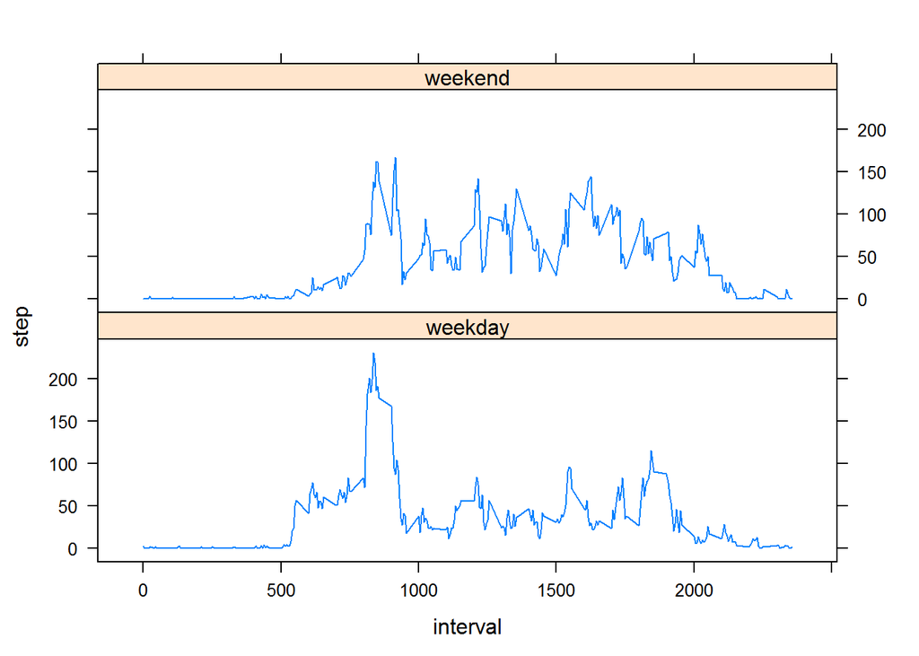

[figure not shown]

```r
xyplot(step ~ interval | week, data= avg_step, type= "l", layout= c(1,2))
```